# Reproducible Research Project 1 - Week 2

### Loading the data

Loading the data using read.csv and setting the default NA strings while reading in as “NA”.

```r
Sys.setenv(TZ = "Asia/Kolkata")
data_activity <- read.csv("./data/activity.csv", na.strings = "NA")
```

```r
head(data_activity)
```

```
##   steps       date interval
## 1    NA 2012-10-01        0
## 2    NA 2012-10-01        5
## 3    NA 2012-10-01       10
## 4    NA 2012-10-01       15
## 5    NA 2012-10-01       20
## 6    NA 2012-10-01       25
```

### Question 1

Transforming the data

Steps to transform data:

1. Convert date variable to date format using lubridate package.
2. Consolidate values by Day.

```r
library(lubridate)
data_activity$date <- ymd(as.character(data_activity$date))
data_activity$day <- wday(data_activity$date, abbr = F, label = T)
```

Consolidating values Total, Mean and Median values of steps taken each day

```r
library(dplyr)
library(tidyr)
steps_measure <- data_activity %>% group_by(day) %>% summarise(steps_sum = sum(steps,
    na.rm = T), steps_mean = mean(steps, na.rm = T), steps_median = median(steps,
    na.rm = T))
```

### Question 2

Plotting the histogram of Total steps taken each day

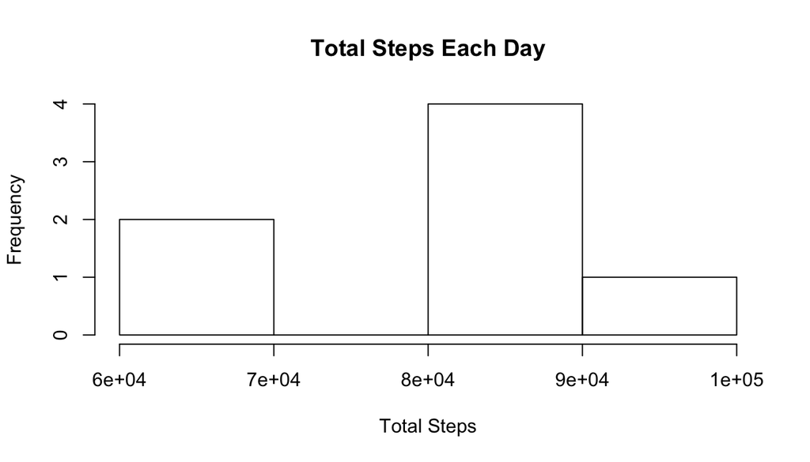

```r
hist(steps_measure$steps_sum, main = "Total Steps Each Day", xlab = "Total Steps")
```

### Question 3

The mean and median number of steps taken each day

```r
library(xtable)
print(xtable(steps_measure[, c("day", "steps_mean", "steps_median")]), type = "html")
```

|  | day | steps_mean | steps_median |
| --- | --- | --- | --- |
| 1 | Sunday | 42.63 | 0.00 |
| 2 | Monday | 34.63 | 0.00 |
| 3 | Tuesday | 31.07 | 0.00 |
| 4 | Wednesday | 40.94 | 0.00 |
| 5 | Thursday | 28.52 | 0.00 |
| 6 | Friday | 42.92 | 0.00 |
| 7 | Saturday | 43.53 | 0.00 |

### Question 4

Time series plot of average number of steps taken(by date)

Steps:

1. Creating a dataframe with values averaged at daily levels.
2. Creating the time series plot.

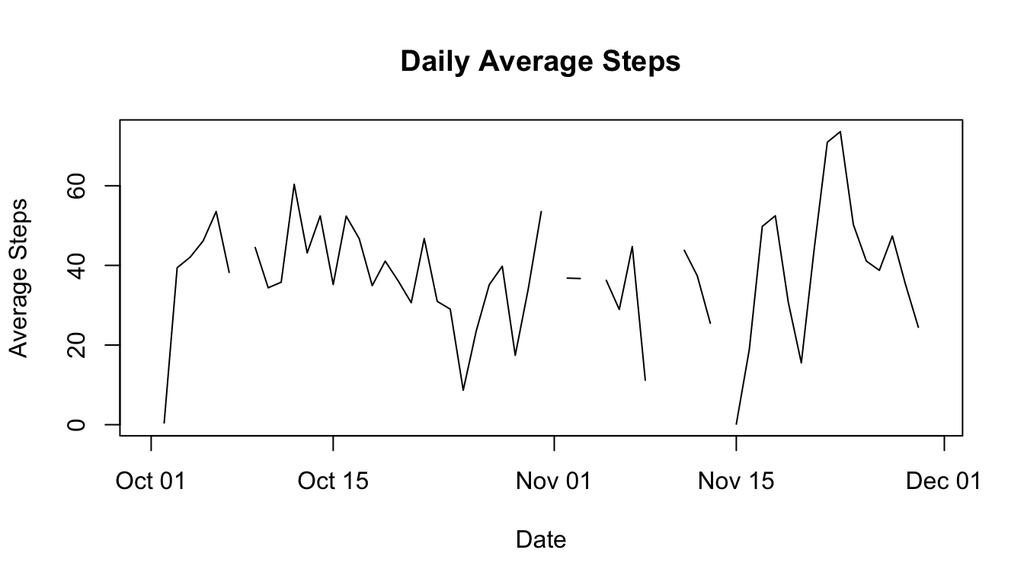

```r
steps_ts <- data_activity %>% group_by(date) %>% summarise(steps_avg = mean(steps,
    na.rm = T))

plot(steps_ts$date, steps_ts$steps_avg, main = "Daily Average Steps", xlab = "Date",
    ylab = "Average Steps", type = "l")
```

### Question 5

Maximum number of steps in an interval

Steps:

1. Create a dataframe with values averages by step intervals
2. Identify the max interval.

```r
steps_int <- data_activity %>% group_by(interval) %>% summarise(steps_avg = mean(steps,
    na.rm = T))

max_int <- steps_int$interval[which.max(steps_int$steps_avg)]
```

The interval 835 has the highest average steps in the data.

### Question 6

Imputing missing data

Steps:

1. Finding the proportion of missing values w.r.t. the complete data.
2. Finding if the data is missing at random or there is a pattern.
3. Using appropriate Missing value imputation technique.
4. Imputing the missing values using **predictive mean matching** (MICE package).

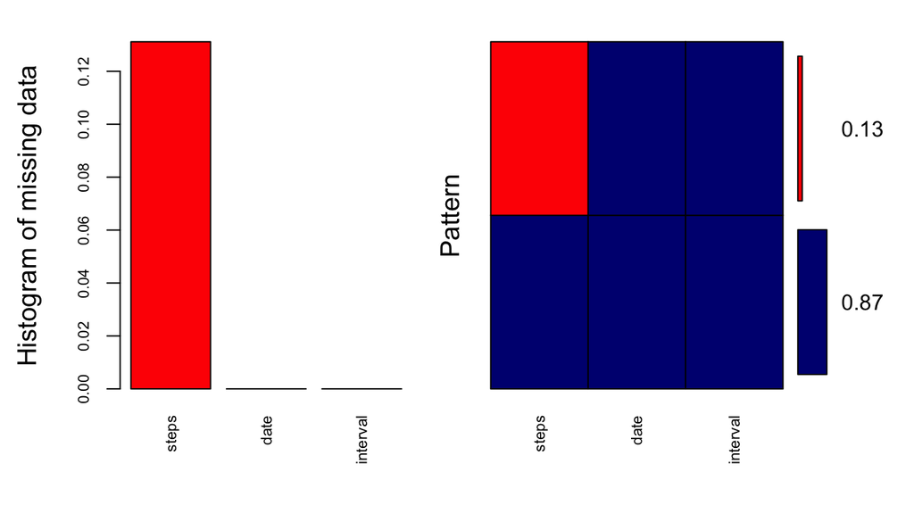

```
##
##  Variables sorted by number of missings:
##  Variable     Count
##     steps 0.1311475
##      date 0.0000000
##  interval 0.0000000
```

```r
library(mice)
library(VIM)
prop_missing <- paste(round(sum(is.na(data_activity$steps))/nrow(data_activity) *
    100, 0), "%")

aggr(data_activity[, c("steps", "date", "interval")], col = c("navyblue", "red"),
    numbers = TRUE, sortVars = TRUE, labels = names(data_activity[, c("steps",
        "date", "interval")]), cex.axis = 0.7, gap = 3, ylab = c("Histogram of missing data",
        "Pattern"))
```

```r
data_activity$month <- month(data_activity$date)
imputed_data <- mice(data_activity[, c("steps", "month", "day", "interval")],
    m = 5, maxit = 2, method = "pmm", seed = 123)
## using the second dataframe imputed values
imputed_data <- complete(imputed_data, 2)
```

Approximately 13 % of the data is missing.

### Question 7

Creating histogram to find total steps taken using imputed data.

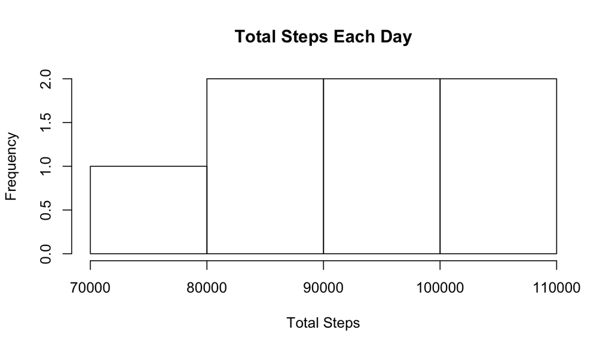

[output not shown]

### Question 8

Panel plot comparing average steps taken per 5-minute interval across weekdays and weekends

Steps:

1. Identify weekdays and weekends in the data.
2. Consolidate at intervals and plot the data.

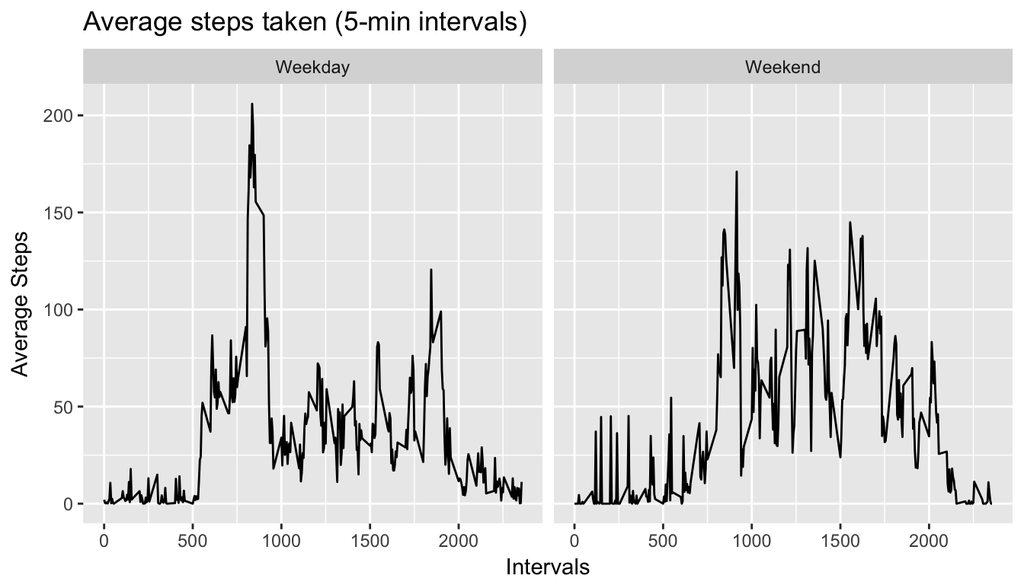